# black_friday_data_exploration

## Problem statement

Predict future sales amount for specific User and Product based on last month sales.

## Exploratory analysis

```python
# Import libraries
import pandas as pd
import pandas_profiling
import numpy as np
import copy

import matplotlib.pyplot as plt
import matplotlib.gridspec as gridspec
import seaborn as sns

from IPython.display import HTML

pd.set_option('display.max_columns', 500)
pd.set_option('display.max_rows', 500)
```

```python
# Read data
path = '/Users/dangloan/Documents/learning_analytics/project/'
df = pd.read_csv(path + '3_data/black_friday/train.csv')
df_test = pd.read_csv(path + '3_data/black_friday/test.csv')
```

```python
# Take an overview of train dataset
profile = pandas_profiling.ProfileReport(df,check_correlation = True)
profile.to_file(outputfile="output.html")
```

Overview

Dataset info

| Number of variables | 12 |
| --- | --- |
| Number of observations | 550068 |
| Total Missing (%) | 8.4% |
| Total size in memory | 50.4 MiB |
| Average record size in memory | 96.0 B |

Variables types

| Numeric | 6 |
| --- | --- |
| Categorical | 5 |
| Boolean | 1 |
| Date | 0 |
| Text (Unique) | 0 |
| Rejected | 0 |
| Unsupported | 0 |

Warnings

- `Occupation` has 69638 / 12.7% zeros Zeros

- `Product_Category_2` has 173638 / 31.6% missing values Missing

- `Product_Category_3` has 383247 / 69.7% missing values Missing

- `Product_ID` has a high cardinality: 3631 distinct values Warning

Variables

Age  
Categorical

| Distinct count | 7 |
| --- | --- |
| Unique (%) | 0.0% |
| Missing (%) | 0.0% |
| Missing (n) | 0 |

| 26-35 | 219587 |
| --- | --- |
| 36-45 | 110013 |
| 18-25 | 99660 |
| Other values (4) | 120808 |

Toggle details

| Value | Count | Frequency (%) |  |
| --- | --- | --- | --- |
| 26-35 | 219587 | 39.9% |  |
| 36-45 | 110013 | 20.0% |  |
| 18-25 | 99660 | 18.1% |  |
| 46-50 | 45701 | 8.3% |  |
| 51-55 | 38501 | 7.0% |  |
| 55+ | 21504 | 3.9% |  |
| 0-17 | 15102 | 2.7% |  |

City_Category  
Categorical

| Distinct count | 3 |
| --- | --- |
| Unique (%) | 0.0% |
| Missing (%) | 0.0% |
| Missing (n) | 0 |

| B | 231173 |
| --- | --- |
| C | 171175 |
| A | 147720 |

Toggle details

| Value | Count | Frequency (%) |  |
| --- | --- | --- | --- |
| B | 231173 | 42.0% |  |
| C | 171175 | 31.1% |  |
| A | 147720 | 26.9% |  |

Gender  
Categorical

| Distinct count | 2 |
| --- | --- |
| Unique (%) | 0.0% |
| Missing (%) | 0.0% |
| Missing (n) | 0 |

| M | 414259 |
| --- | --- |
| F | 135809 |

Toggle details

| Value | Count | Frequency (%) |  |
| --- | --- | --- | --- |
| M | 414259 | 75.3% |  |
| F | 135809 | 24.7% |  |

Marital_Status  
Boolean

| Distinct count | 2 |
| --- | --- |
| Unique (%) | 0.0% |
| Missing (%) | 0.0% |
| Missing (n) | 0 |

| Mean | 0.40965 |
| --- | --- |

| 0 | 324731 |
| --- | --- |
| 1 | 225337 |

Toggle details

| Value | Count | Frequency (%) |  |
| --- | --- | --- | --- |
| 0 | 324731 | 59.0% |  |
| 1 | 225337 | 41.0% |  |

Occupation  
Numeric

| Distinct count | 21 |
| --- | --- |
| Unique (%) | 0.0% |
| Missing (%) | 0.0% |
| Missing (n) | 0 |
| Infinite (%) | 0.0% |
| Infinite (n) | 0 |

| Mean | 8.0767 |
| --- | --- |
| Minimum | 0 |
| Maximum | 20 |
| Zeros (%) | 12.7% |

Toggle details

**Statistics**

Quantile statistics

| Minimum | 0 |
| --- | --- |
| 5-th percentile | 0 |
| Q1 | 2 |
| Median | 7 |
| Q3 | 14 |
| 95-th percentile | 20 |
| Maximum | 20 |
| Range | 20 |
| Interquartile range | 12 |

Descriptive statistics

| Standard deviation | 6.5227 |
| --- | --- |
| Coef of variation | 0.80759 |
| Kurtosis | -1.2161 |
| Mean | 8.0767 |
| MAD | 5.7722 |
| Skewness | 0.40014 |
| Sum | 4442738 |
| Variance | 42.545 |
| Memory size | 4.2 MiB |

**Histogram**

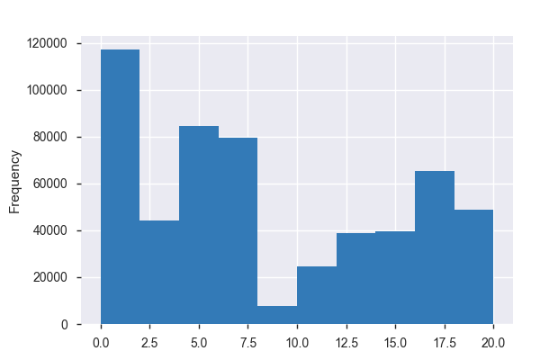

**Common Values**

| Value | Count | Frequency (%) |  |
| --- | --- | --- | --- |
| 4 | 72308 | 13.1% |  |
| 0 | 69638 | 12.7% |  |
| 7 | 59133 | 10.8% |  |
| 1 | 47426 | 8.6% |  |
| 17 | 40043 | 7.3% |  |
| 20 | 33562 | 6.1% |  |
| 12 | 31179 | 5.7% |  |
| 14 | 27309 | 5.0% |  |
| 2 | 26588 | 4.8% |  |
| 16 | 25371 | 4.6% |  |
| Other values (11) | 117511 | 21.4% |  |

**Extreme Values**

Minimum 5 values

| Value | Count | Frequency (%) |  |
| --- | --- | --- | --- |
| 0 | 69638 | 12.7% |  |
| 1 | 47426 | 8.6% |  |
| 2 | 26588 | 4.8% |  |
| 3 | 17650 | 3.2% |  |
| 4 | 72308 | 13.1% |  |

Maximum 5 values

| Value | Count | Frequency (%) |  |
| --- | --- | --- | --- |
| 16 | 25371 | 4.6% |  |
| 17 | 40043 | 7.3% |  |
| 18 | 6622 | 1.2% |  |
| 19 | 8461 | 1.5% |  |
| 20 | 33562 | 6.1% |  |

Product_Category_1  
Numeric

| Distinct count | 20 |
| --- | --- |
| Unique (%) | 0.0% |
| Missing (%) | 0.0% |
| Missing (n) | 0 |
| Infinite (%) | 0.0% |
| Infinite (n) | 0 |

| Mean | 5.4043 |
| --- | --- |
| Minimum | 1 |
| Maximum | 20 |
| Zeros (%) | 0.0% |

Toggle details

**Statistics**

Quantile statistics

| Minimum | 1 |
| --- | --- |
| 5-th percentile | 1 |
| Q1 | 1 |
| Median | 5 |
| Q3 | 8 |
| 95-th percentile | 13 |
| Maximum | 20 |
| Range | 19 |
| Interquartile range | 7 |

Descriptive statistics

| Standard deviation | 3.9362 |
| --- | --- |
| Coef of variation | 0.72835 |
| Kurtosis | 1.2348 |
| Mean | 5.4043 |
| MAD | 3.0019 |
| Skewness | 1.0257 |
| Sum | 2972716 |
| Variance | 15.494 |
| Memory size | 4.2 MiB |

**Histogram**

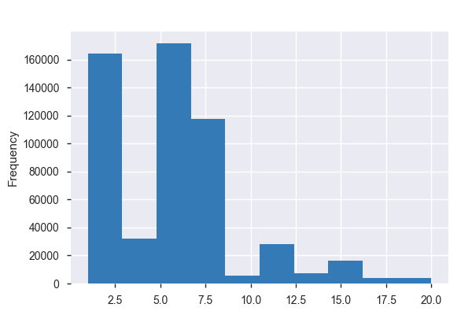

**Common Values**

| Value | Count | Frequency (%) |  |
| --- | --- | --- | --- |
| 5 | 150933 | 27.4% |  |
| 1 | 140378 | 25.5% |  |
| 8 | 113925 | 20.7% |  |
| 11 | 24287 | 4.4% |  |
| 2 | 23864 | 4.3% |  |
| 6 | 20466 | 3.7% |  |
| 3 | 20213 | 3.7% |  |
| 4 | 11753 | 2.1% |  |
| 16 | 9828 | 1.8% |  |
| 15 | 6290 | 1.1% |  |
| Other values (10) | 28131 | 5.1% |  |

**Extreme Values**

Minimum 5 values

| Value | Count | Frequency (%) |  |
| --- | --- | --- | --- |
| 1 | 140378 | 25.5% |  |
| 2 | 23864 | 4.3% |  |
| 3 | 20213 | 3.7% |  |
| 4 | 11753 | 2.1% |  |
| 5 | 150933 | 27.4% |  |

Maximum 5 values

| Value | Count | Frequency (%) |  |
| --- | --- | --- | --- |
| 16 | 9828 | 1.8% |  |
| 17 | 578 | 0.1% |  |
| 18 | 3125 | 0.6% |  |
| 19 | 1603 | 0.3% |  |
| 20 | 2550 | 0.5% |  |

Product_Category_2  
Numeric

| Distinct count | 18 |
| --- | --- |
| Unique (%) | 0.0% |
| Missing (%) | 31.6% |
| Missing (n) | 173638 |
| Infinite (%) | 0.0% |
| Infinite (n) | 0 |

| Mean | 9.8423 |
| --- | --- |
| Minimum | 2 |
| Maximum | 18 |
| Zeros (%) | 0.0% |

Toggle details

**Statistics**

Quantile statistics

| Minimum | 2 |
| --- | --- |
| 5-th percentile | 2 |
| Q1 | 5 |
| Median | 9 |
| Q3 | 15 |
| 95-th percentile | 16 |
| Maximum | 18 |
| Range | 16 |
| Interquartile range | 10 |

Descriptive statistics

| Standard deviation | 5.0866 |
| --- | --- |
| Coef of variation | 0.51681 |
| Kurtosis | -1.4323 |
| Mean | 9.8423 |
| MAD | 4.626 |
| Skewness | -0.16276 |
| Sum | 3704900 |
| Variance | 25.873 |
| Memory size | 4.2 MiB |

**Histogram**

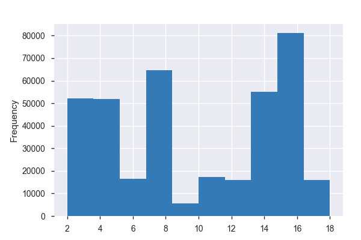

**Common Values**

| Value | Count | Frequency (%) |  |
| --- | --- | --- | --- |
| 8.0 | 64088 | 11.7% |  |
| 14.0 | 55108 | 10.0% |  |
| 2.0 | 49217 | 8.9% |  |
| 16.0 | 43255 | 7.9% |  |
| 15.0 | 37855 | 6.9% |  |
| 5.0 | 26235 | 4.8% |  |
| 4.0 | 25677 | 4.7% |  |
| 6.0 | 16466 | 3.0% |  |
| 11.0 | 14134 | 2.6% |  |
| 17.0 | 13320 | 2.4% |  |
| Other values (7) | 31075 | 5.6% |  |
| (Missing) | 173638 | 31.6% |  |

**Extreme Values**

Minimum 5 values

| Value | Count | Frequency (%) |  |
| --- | --- | --- | --- |
| 2.0 | 49217 | 8.9% |  |
| 3.0 | 2884 | 0.5% |  |
| 4.0 | 25677 | 4.7% |  |
| 5.0 | 26235 | 4.8% |  |
| 6.0 | 16466 | 3.0% |  |

Maximum 5 values

| Value | Count | Frequency (%) |  |
| --- | --- | --- | --- |
| 14.0 | 55108 | 10.0% |  |
| 15.0 | 37855 | 6.9% |  |
| 16.0 | 43255 | 7.9% |  |
| 17.0 | 13320 | 2.4% |  |
| 18.0 | 2770 | 0.5% |  |

Product_Category_3  
Numeric

| Distinct count | 16 |
| --- | --- |
| Unique (%) | 0.0% |
| Missing (%) | 69.7% |
| Missing (n) | 383247 |
| Infinite (%) | 0.0% |
| Infinite (n) | 0 |

| Mean | 12.668 |
| --- | --- |
| Minimum | 3 |
| Maximum | 18 |
| Zeros (%) | 0.0% |

Toggle details

**Statistics**

Quantile statistics

| Minimum | 3 |
| --- | --- |
| 5-th percentile | 5 |
| Q1 | 9 |
| Median | 14 |
| Q3 | 16 |
| 95-th percentile | 17 |
| Maximum | 18 |
| Range | 15 |
| Interquartile range | 7 |

Descriptive statistics

| Standard deviation | 4.1253 |
| --- | --- |
| Coef of variation | 0.32564 |
| Kurtosis | -0.80807 |
| Mean | 12.668 |
| MAD | 3.5659 |
| Skewness | -0.76545 |
| Sum | 2113300 |
| Variance | 17.018 |
| Memory size | 4.2 MiB |

**Histogram**

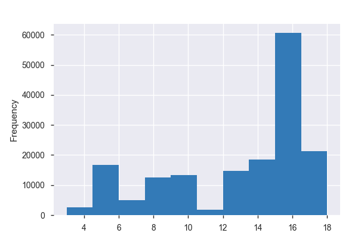

**Common Values**

| Value | Count | Frequency (%) |  |
| --- | --- | --- | --- |
| 16.0 | 32636 | 5.9% |  |
| 15.0 | 28013 | 5.1% |  |
| 14.0 | 18428 | 3.4% |  |
| 17.0 | 16702 | 3.0% |  |
| 5.0 | 16658 | 3.0% |  |
| 8.0 | 12562 | 2.3% |  |
| 9.0 | 11579 | 2.1% |  |
| 12.0 | 9246 | 1.7% |  |
| 13.0 | 5459 | 1.0% |  |
| 6.0 | 4890 | 0.9% |  |
| Other values (5) | 10648 | 1.9% |  |
| (Missing) | 383247 | 69.7% |  |

**Extreme Values**

Minimum 5 values

| Value | Count | Frequency (%) |  |
| --- | --- | --- | --- |
| 3.0 | 613 | 0.1% |  |
| 4.0 | 1875 | 0.3% |  |
| 5.0 | 16658 | 3.0% |  |
| 6.0 | 4890 | 0.9% |  |
| 8.0 | 12562 | 2.3% |  |

Maximum 5 values

| Value | Count | Frequency (%) |  |
| --- | --- | --- | --- |
| 14.0 | 18428 | 3.4% |  |
| 15.0 | 28013 | 5.1% |  |
| 16.0 | 32636 | 5.9% |  |
| 17.0 | 16702 | 3.0% |  |
| 18.0 | 4629 | 0.8% |  |

Product_ID  
Categorical

| Distinct count | 3631 |
| --- | --- |
| Unique (%) | 0.7% |
| Missing (%) | 0.0% |
| Missing (n) | 0 |

| P00265242 | 1880 |
| --- | --- |
| P00025442 | 1615 |
| P00110742 | 1612 |
| Other values (3628) | 544961 |

Toggle details

| Value | Count | Frequency (%) |  |
| --- | --- | --- | --- |
| P00265242 | 1880 | 0.3% |  |
| P00025442 | 1615 | 0.3% |  |
| P00110742 | 1612 | 0.3% |  |
| P00112142 | 1562 | 0.3% |  |
| P00057642 | 1470 | 0.3% |  |
| P00184942 | 1440 | 0.3% |  |
| P00046742 | 1438 | 0.3% |  |
| P00058042 | 1422 | 0.3% |  |
| P00059442 | 1406 | 0.3% |  |
| P00145042 | 1406 | 0.3% |  |
| Other values (3621) | 534817 | 97.2% |  |

Purchase  
Numeric

| Distinct count | 18105 |
| --- | --- |
| Unique (%) | 3.3% |
| Missing (%) | 0.0% |
| Missing (n) | 0 |
| Infinite (%) | 0.0% |
| Infinite (n) | 0 |

| Mean | 9264 |
| --- | --- |
| Minimum | 12 |
| Maximum | 23961 |
| Zeros (%) | 0.0% |

Toggle details

**Statistics**

Quantile statistics

| Minimum | 12 |
| --- | --- |
| 5-th percentile | 1984 |
| Q1 | 5823 |
| Median | 8047 |
| Q3 | 12054 |
| 95-th percentile | 19336 |
| Maximum | 23961 |
| Range | 23949 |
| Interquartile range | 6231 |

Descriptive statistics

| Standard deviation | 5023.1 |
| --- | --- |
| Coef of variation | 0.54222 |
| Kurtosis | -0.33838 |
| Mean | 9264 |
| MAD | 4070 |
| Skewness | 0.60014 |
| Sum | 5095812742 |
| Variance | 25231000 |
| Memory size | 4.2 MiB |

**Histogram**

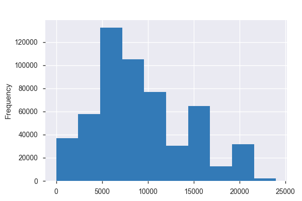

**Common Values**

| Value | Count | Frequency (%) |  |
| --- | --- | --- | --- |
| 7011 | 191 | 0.0% |  |
| 7193 | 188 | 0.0% |  |
| 6855 | 187 | 0.0% |  |
| 6891 | 184 | 0.0% |  |
| 6960 | 183 | 0.0% |  |
| 7012 | 183 | 0.0% |  |
| 6879 | 182 | 0.0% |  |
| 7166 | 182 | 0.0% |  |
| 7027 | 182 | 0.0% |  |
| 7165 | 180 | 0.0% |  |
| Other values (18095) | 548226 | 99.7% |  |

**Extreme Values**

Minimum 5 values

| Value | Count | Frequency (%) |  |
| --- | --- | --- | --- |
| 12 | 101 | 0.0% |  |
| 13 | 106 | 0.0% |  |
| 14 | 95 | 0.0% |  |
| 24 | 118 | 0.0% |  |
| 25 | 113 | 0.0% |  |

Maximum 5 values

| Value | Count | Frequency (%) |  |
| --- | --- | --- | --- |
| 23956 | 1 | 0.0% |  |
| 23958 | 4 | 0.0% |  |
| 23959 | 2 | 0.0% |  |
| 23960 | 4 | 0.0% |  |
| 23961 | 3 | 0.0% |  |

Stay_In_Current_City_Years  
Categorical

| Distinct count | 5 |
| --- | --- |
| Unique (%) | 0.0% |
| Missing (%) | 0.0% |
| Missing (n) | 0 |

| 1 | 193821 |
| --- | --- |
| 2 | 101838 |
| 3 | 95285 |
| Other values (2) | 159124 |

Toggle details

| Value | Count | Frequency (%) |  |
| --- | --- | --- | --- |
| 1 | 193821 | 35.2% |  |
| 2 | 101838 | 18.5% |  |
| 3 | 95285 | 17.3% |  |
| 4+ | 84726 | 15.4% |  |
| 0 | 74398 | 13.5% |  |

User_ID  
Numeric

| Distinct count | 5891 |
| --- | --- |
| Unique (%) | 1.1% |
| Missing (%) | 0.0% |
| Missing (n) | 0 |
| Infinite (%) | 0.0% |
| Infinite (n) | 0 |

| Mean | 1003000 |
| --- | --- |
| Minimum | 1000001 |
| Maximum | 1006040 |
| Zeros (%) | 0.0% |

Toggle details

**Statistics**

Quantile statistics

| Minimum | 1000001 |
| --- | --- |
| 5-th percentile | 1000300 |
| Q1 | 1001500 |
| Median | 1003100 |
| Q3 | 1004500 |
| 95-th percentile | 1005700 |
| Maximum | 1006040 |
| Range | 6039 |
| Interquartile range | 2962 |

Descriptive statistics

| Standard deviation | 1727.6 |
| --- | --- |
| Coef of variation | 0.0017224 |
| Kurtosis | -1.1955 |
| Mean | 1003000 |
| MAD | 1500 |
| Skewness | 0.0030656 |
| Sum | 551734069282 |
| Variance | 2984600 |
| Memory size | 4.2 MiB |

**Histogram**

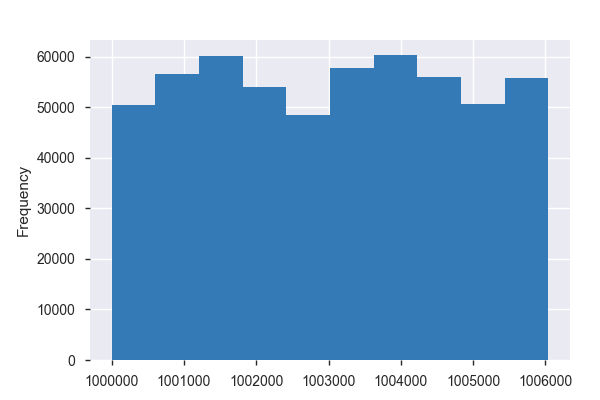

**Common Values**

| Value | Count | Frequency (%) |  |
| --- | --- | --- | --- |
| 1001680 | 1026 | 0.2% |  |
| 1004277 | 979 | 0.2% |  |
| 1001941 | 898 | 0.2% |  |
| 1001181 | 862 | 0.2% |  |
| 1000889 | 823 | 0.1% |  |
| 1003618 | 767 | 0.1% |  |
| 1001150 | 752 | 0.1% |  |
| 1001015 | 740 | 0.1% |  |
| 1005795 | 729 | 0.1% |  |
| 1005831 | 727 | 0.1% |  |
| Other values (5881) | 541765 | 98.5% |  |

**Extreme Values**

Minimum 5 values

| Value | Count | Frequency (%) |  |
| --- | --- | --- | --- |
| 1000001 | 35 | 0.0% |  |
| 1000002 | 77 | 0.0% |  |
| 1000003 | 29 | 0.0% |  |
| 1000004 | 14 | 0.0% |  |
| 1000005 | 106 | 0.0% |  |

Maximum 5 values

| Value | Count | Frequency (%) |  |
| --- | --- | --- | --- |
| 1006036 | 514 | 0.1% |  |
| 1006037 | 122 | 0.0% |  |
| 1006038 | 12 | 0.0% |  |
| 1006039 | 74 | 0.0% |  |
| 1006040 | 180 | 0.0% |  |

Correlations

Sample

|  | User_ID | Product_ID | Gender | Age | Occupation | City_Category | Stay_In_Current_City_Years | Marital_Status | Product_Category_1 | Product_Category_2 | Product_Category_3 | Purchase |
| --- | --- | --- | --- | --- | --- | --- | --- | --- | --- | --- | --- | --- |
| 0 | 1000001 | P00069042 | F | 0-17 | 10 | A | 2 | 0 | 3 | NaN | NaN | 8370 |
| 1 | 1000001 | P00248942 | F | 0-17 | 10 | A | 2 | 0 | 1 | 6.0 | 14.0 | 15200 |
| 2 | 1000001 | P00087842 | F | 0-17 | 10 | A | 2 | 0 | 12 | NaN | NaN | 1422 |
| 3 | 1000001 | P00085442 | F | 0-17 | 10 | A | 2 | 0 | 12 | 14.0 | NaN | 1057 |
| 4 | 1000002 | P00285442 | M | 55+ | 16 | C | 4+ | 0 | 8 | NaN | NaN | 7969 |

```python
profile
```

Now take a look at test data set to see if distribution is similar to train data

Overview

Dataset info

| Number of variables | 11 |
| --- | --- |
| Number of observations | 233599 |
| Total Missing (%) | 9.1% |
| Total size in memory | 19.6 MiB |
| Average record size in memory | 88.0 B |

Variables types

| Numeric | 5 |
| --- | --- |
| Categorical | 5 |
| Boolean | 1 |
| Date | 0 |
| Text (Unique) | 0 |
| Rejected | 0 |
| Unsupported | 0 |

Warnings

- `Occupation` has 29212 / 12.5% zeros Zeros

- `Product_Category_2` has 72344 / 31.0% missing values Missing

- `Product_Category_3` has 162562 / 69.6% missing values Missing

- `Product_ID` has a high cardinality: 3491 distinct values Warning

Variables

Age  
Categorical

| Distinct count | 7 |
| --- | --- |
| Unique (%) | 0.0% |
| Missing (%) | 0.0% |
| Missing (n) | 0 |

| 26-35 | 93428 |
| --- | --- |
| 36-45 | 46711 |
| 18-25 | 42293 |
| Other values (4) | 51167 |

Toggle details

| Value | Count | Frequency (%) |  |
| --- | --- | --- | --- |
| 26-35 | 93428 | 40.0% |  |
| 36-45 | 46711 | 20.0% |  |
| 18-25 | 42293 | 18.1% |  |
| 46-50 | 19577 | 8.4% |  |
| 51-55 | 16283 | 7.0% |  |
| 55+ | 9075 | 3.9% |  |
| 0-17 | 6232 | 2.7% |  |

City_Category  
Categorical

| Distinct count | 3 |
| --- | --- |
| Unique (%) | 0.0% |
| Missing (%) | 0.0% |
| Missing (n) | 0 |

| B | 98566 |
| --- | --- |
| C | 72509 |
| A | 62524 |

Toggle details

| Value | Count | Frequency (%) |  |
| --- | --- | --- | --- |
| B | 98566 | 42.2% |  |
| C | 72509 | 31.0% |  |
| A | 62524 | 26.8% |  |

Gender  
Categorical

| Distinct count | 2 |
| --- | --- |
| Unique (%) | 0.0% |
| Missing (%) | 0.0% |
| Missing (n) | 0 |

| M | 175772 |
| --- | --- |
| F | 57827 |

Toggle details

| Value | Count | Frequency (%) |  |
| --- | --- | --- | --- |
| M | 175772 | 75.2% |  |
| F | 57827 | 24.8% |  |

Marital_Status  
Boolean

| Distinct count | 2 |
| --- | --- |
| Unique (%) | 0.0% |
| Missing (%) | 0.0% |
| Missing (n) | 0 |

| Mean | 0.41007 |
| --- | --- |

| 0 | 137807 |
| --- | --- |
| 1 | 95792 |

Toggle details

| Value | Count | Frequency (%) |  |
| --- | --- | --- | --- |
| 0 | 137807 | 59.0% |  |
| 1 | 95792 | 41.0% |  |

Occupation  
Numeric

| Distinct count | 21 |
| --- | --- |
| Unique (%) | 0.0% |
| Missing (%) | 0.0% |
| Missing (n) | 0 |
| Infinite (%) | 0.0% |
| Infinite (n) | 0 |

| Mean | 8.0854 |
| --- | --- |
| Minimum | 0 |
| Maximum | 20 |
| Zeros (%) | 12.5% |

Toggle details

**Statistics**

Quantile statistics

| Minimum | 0 |
| --- | --- |
| 5-th percentile | 0 |
| Q1 | 2 |
| Median | 7 |
| Q3 | 14 |
| 95-th percentile | 20 |
| Maximum | 20 |
| Range | 20 |
| Interquartile range | 12 |

Descriptive statistics

| Standard deviation | 6.5211 |
| --- | --- |
| Coef of variation | 0.80653 |
| Kurtosis | -1.2188 |
| Mean | 8.0854 |
| MAD | 5.7739 |
| Skewness | 0.39889 |
| Sum | 1888743 |
| Variance | 42.525 |
| Memory size | 1.8 MiB |

**Histogram**

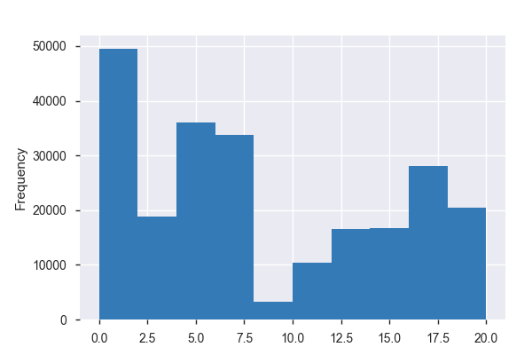

**Common Values**

| Value | Count | Frequency (%) |  |
| --- | --- | --- | --- |
| 4 | 30778 | 13.2% |  |
| 0 | 29212 | 12.5% |  |
| 7 | 24994 | 10.7% |  |
| 1 | 20261 | 8.7% |  |
| 17 | 17375 | 7.4% |  |
| 20 | 14278 | 6.1% |  |
| 12 | 13269 | 5.7% |  |
| 14 | 11473 | 4.9% |  |
| 2 | 11408 | 4.9% |  |
| 16 | 10751 | 4.6% |  |
| Other values (11) | 49800 | 21.3% |  |

**Extreme Values**

Minimum 5 values

| Value | Count | Frequency (%) |  |
| --- | --- | --- | --- |
| 0 | 29212 | 12.5% |  |
| 1 | 20261 | 8.7% |  |
| 2 | 11408 | 4.9% |  |
| 3 | 7476 | 3.2% |  |
| 4 | 30778 | 13.2% |  |

Maximum 5 values

| Value | Count | Frequency (%) |  |
| --- | --- | --- | --- |
| 16 | 10751 | 4.6% |  |
| 17 | 17375 | 7.4% |  |
| 18 | 2745 | 1.2% |  |
| 19 | 3458 | 1.5% |  |
| 20 | 14278 | 6.1% |  |

Product_Category_1  
Numeric

| Distinct count | 18 |
| --- | --- |
| Unique (%) | 0.0% |
| Missing (%) | 0.0% |
| Missing (n) | 0 |
| Infinite (%) | 0.0% |
| Infinite (n) | 0 |

| Mean | 5.2765 |
| --- | --- |
| Minimum | 1 |
| Maximum | 18 |
| Zeros (%) | 0.0% |

Toggle details

**Statistics**

Quantile statistics

| Minimum | 1 |
| --- | --- |
| 5-th percentile | 1 |
| Q1 | 1 |
| Median | 5 |
| Q3 | 8 |
| 95-th percentile | 12 |
| Maximum | 18 |
| Range | 17 |
| Interquartile range | 7 |

Descriptive statistics

| Standard deviation | 3.7364 |
| --- | --- |
| Coef of variation | 0.70811 |
| Kurtosis | 0.71138 |
| Mean | 5.2765 |
| MAD | 2.8703 |
| Skewness | 0.86917 |
| Sum | 1232595 |
| Variance | 13.961 |
| Memory size | 1.8 MiB |

**Histogram**

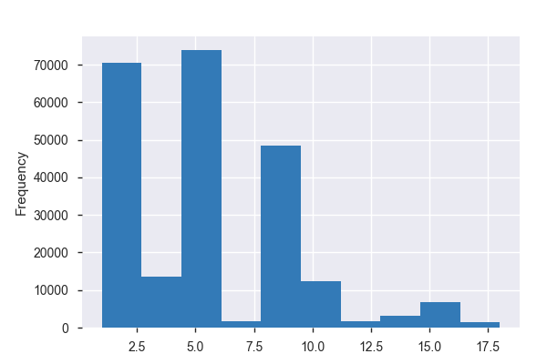

**Common Values**

| Value | Count | Frequency (%) |  |
| --- | --- | --- | --- |
| 5 | 65017 | 27.8% |  |
| 1 | 60321 | 25.8% |  |
| 8 | 48369 | 20.7% |  |
| 2 | 10192 | 4.4% |  |
| 11 | 10153 | 4.3% |  |
| 6 | 8860 | 3.8% |  |
| 3 | 8578 | 3.7% |  |
| 4 | 5003 | 2.1% |  |
| 16 | 4105 | 1.8% |  |
| 15 | 2694 | 1.2% |  |
| Other values (8) | 10307 | 4.4% |  |

**Extreme Values**

Minimum 5 values

| Value | Count | Frequency (%) |  |
| --- | --- | --- | --- |
| 1 | 60321 | 25.8% |  |
| 2 | 10192 | 4.4% |  |
| 3 | 8578 | 3.7% |  |
| 4 | 5003 | 2.1% |  |
| 5 | 65017 | 27.8% |  |

Maximum 5 values

| Value | Count | Frequency (%) |  |
| --- | --- | --- | --- |
| 14 | 663 | 0.3% |  |
| 15 | 2694 | 1.2% |  |
| 16 | 4105 | 1.8% |  |
| 17 | 223 | 0.1% |  |
| 18 | 1311 | 0.6% |  |

Product_Category_2  
Numeric

| Distinct count | 18 |
| --- | --- |
| Unique (%) | 0.0% |
| Missing (%) | 31.0% |
| Missing (n) | 72344 |
| Infinite (%) | 0.0% |
| Infinite (n) | 0 |

| Mean | 9.8496 |
| --- | --- |
| Minimum | 2 |
| Maximum | 18 |
| Zeros (%) | 0.0% |

Toggle details

**Statistics**

Quantile statistics

| Minimum | 2 |
| --- | --- |
| 5-th percentile | 2 |
| Q1 | 5 |
| Median | 9 |
| Q3 | 15 |
| 95-th percentile | 16 |
| Maximum | 18 |
| Range | 16 |
| Interquartile range | 10 |

Descriptive statistics

| Standard deviation | 5.0949 |
| --- | --- |
| Coef of variation | 0.51727 |
| Kurtosis | -1.4318 |
| Mean | 9.8496 |
| MAD | 4.6329 |
| Skewness | -0.1667 |
| Sum | 1588300 |
| Variance | 25.958 |
| Memory size | 1.8 MiB |

**Histogram**

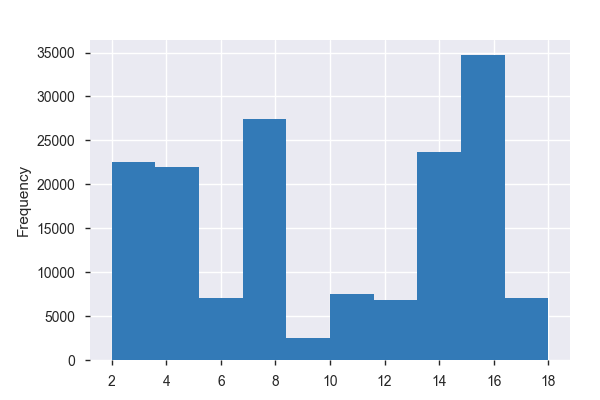

**Common Values**

| Value | Count | Frequency (%) |  |
| --- | --- | --- | --- |
| 8.0 | 27229 | 11.7% |  |
| 14.0 | 23726 | 10.2% |  |
| 2.0 | 21281 | 9.1% |  |
| 16.0 | 18432 | 7.9% |  |
| 15.0 | 16259 | 7.0% |  |
| 4.0 | 11028 | 4.7% |  |
| 5.0 | 10930 | 4.7% |  |
| 6.0 | 7109 | 3.0% |  |
| 11.0 | 6096 | 2.6% |  |
| 17.0 | 5784 | 2.5% |  |
| Other values (7) | 13381 | 5.7% |  |
| (Missing) | 72344 | 31.0% |  |

**Extreme Values**

Minimum 5 values

| Value | Count | Frequency (%) |  |
| --- | --- | --- | --- |
| 2.0 | 21281 | 9.1% |  |
| 3.0 | 1239 | 0.5% |  |
| 4.0 | 11028 | 4.7% |  |
| 5.0 | 10930 | 4.7% |  |
| 6.0 | 7109 | 3.0% |  |

Maximum 5 values

| Value | Count | Frequency (%) |  |
| --- | --- | --- | --- |
| 14.0 | 23726 | 10.2% |  |
| 15.0 | 16259 | 7.0% |  |
| 16.0 | 18432 | 7.9% |  |
| 17.0 | 5784 | 2.5% |  |
| 18.0 | 1257 | 0.5% |  |

Product_Category_3  
Numeric

| Distinct count | 16 |
| --- | --- |
| Unique (%) | 0.0% |
| Missing (%) | 69.6% |
| Missing (n) | 162562 |
| Infinite (%) | 0.0% |
| Infinite (n) | 0 |

| Mean | 12.669 |
| --- | --- |
| Minimum | 3 |
| Maximum | 18 |
| Zeros (%) | 0.0% |

Toggle details

**Statistics**

Quantile statistics

| Minimum | 3 |
| --- | --- |
| 5-th percentile | 5 |
| Q1 | 9 |
| Median | 14 |
| Q3 | 16 |
| 95-th percentile | 17 |
| Maximum | 18 |
| Range | 15 |
| Interquartile range | 7 |

Descriptive statistics

| Standard deviation | 4.1259 |
| --- | --- |
| Coef of variation | 0.32566 |
| Kurtosis | -0.80233 |
| Mean | 12.669 |
| MAD | 3.5646 |
| Skewness | -0.76737 |
| Sum | 900000 |
| Variance | 17.023 |
| Memory size | 1.8 MiB |

**Histogram**

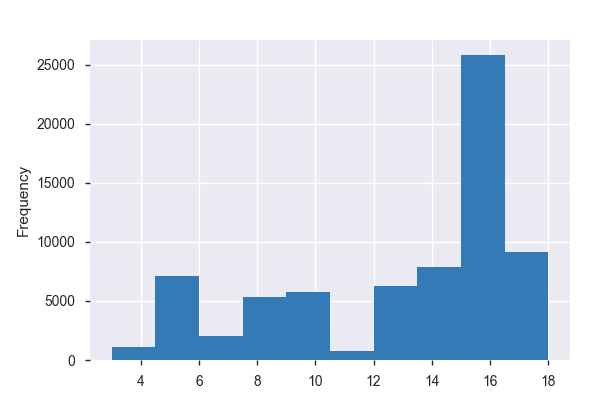

**Common Values**

| Value | Count | Frequency (%) |  |
| --- | --- | --- | --- |
| 16.0 | 13833 | 5.9% |  |
| 15.0 | 11955 | 5.1% |  |
| 14.0 | 7855 | 3.4% |  |
| 5.0 | 7141 | 3.1% |  |
| 17.0 | 7116 | 3.0% |  |
| 8.0 | 5299 | 2.3% |  |
| 9.0 | 4953 | 2.1% |  |
| 12.0 | 3869 | 1.7% |  |
| 13.0 | 2390 | 1.0% |  |
| 6.0 | 1998 | 0.9% |  |
| Other values (5) | 4628 | 2.0% |  |
| (Missing) | 162562 | 69.6% |  |

**Extreme Values**

Minimum 5 values

| Value | Count | Frequency (%) |  |
| --- | --- | --- | --- |
| 3.0 | 265 | 0.1% |  |
| 4.0 | 816 | 0.3% |  |
| 5.0 | 7141 | 3.1% |  |
| 6.0 | 1998 | 0.9% |  |
| 8.0 | 5299 | 2.3% |  |

Maximum 5 values

| Value | Count | Frequency (%) |  |
| --- | --- | --- | --- |
| 14.0 | 7855 | 3.4% |  |
| 15.0 | 11955 | 5.1% |  |
| 16.0 | 13833 | 5.9% |  |
| 17.0 | 7116 | 3.0% |  |
| 18.0 | 1992 | 0.9% |  |

Product_ID  
Categorical

| Distinct count | 3491 |
| --- | --- |
| Unique (%) | 1.5% |
| Missing (%) | 0.0% |
| Missing (n) | 0 |

| P00265242 | 829 |
| --- | --- |
| P00112142 | 717 |
| P00025442 | 695 |
| Other values (3488) | 231358 |

Toggle details

| Value | Count | Frequency (%) |  |
| --- | --- | --- | --- |
| P00265242 | 829 | 0.4% |  |
| P00112142 | 717 | 0.3% |  |
| P00025442 | 695 | 0.3% |  |
| P00110742 | 680 | 0.3% |  |
| P00046742 | 646 | 0.3% |  |
| P00184942 | 626 | 0.3% |  |
| P00117942 | 621 | 0.3% |  |
| P00110942 | 616 | 0.3% |  |
| P00057642 | 609 | 0.3% |  |
| P00237542 | 605 | 0.3% |  |
| Other values (3481) | 226955 | 97.2% |  |

Stay_In_Current_City_Years  
Categorical

| Distinct count | 5 |
| --- | --- |
| Unique (%) | 0.0% |
| Missing (%) | 0.0% |
| Missing (n) | 0 |

| 1 | 82604 |
| --- | --- |
| 2 | 43589 |
| 3 | 40143 |
| Other values (2) | 67263 |

Toggle details

| Value | Count | Frequency (%) |  |
| --- | --- | --- | --- |
| 1 | 82604 | 35.4% |  |
| 2 | 43589 | 18.7% |  |
| 3 | 40143 | 17.2% |  |
| 4+ | 35945 | 15.4% |  |
| 0 | 31318 | 13.4% |  |

User_ID  
Numeric

| Distinct count | 5891 |
| --- | --- |
| Unique (%) | 2.5% |
| Missing (%) | 0.0% |
| Missing (n) | 0 |
| Infinite (%) | 0.0% |
| Infinite (n) | 0 |

| Mean | 1003000 |
| --- | --- |
| Minimum | 1000001 |
| Maximum | 1006040 |
| Zeros (%) | 0.0% |

Toggle details

**Statistics**

Quantile statistics

| Minimum | 1000001 |
| --- | --- |
| 5-th percentile | 1000300 |
| Q1 | 1001500 |
| Median | 1003100 |
| Q3 | 1004500 |
| 95-th percentile | 1005700 |
| Maximum | 1006040 |
| Range | 6039 |
| Interquartile range | 2950 |

Descriptive statistics

| Standard deviation | 1726.5 |
| --- | --- |
| Coef of variation | 0.0017213 |
| Kurtosis | -1.1929 |
| Mean | 1003000 |
| MAD | 1498.5 |
| Skewness | 0.0028839 |
| Sum | 234306654733 |
| Variance | 2980800 |
| Memory size | 1.8 MiB |

**Histogram**

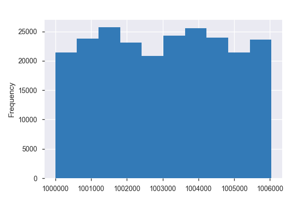

**Common Values**

| Value | Count | Frequency (%) |  |
| --- | --- | --- | --- |
| 1001680 | 442 | 0.2% |  |
| 1004277 | 405 | 0.2% |  |
| 1001941 | 388 | 0.2% |  |
| 1000889 | 381 | 0.2% |  |
| 1001181 | 368 | 0.2% |  |
| 1004344 | 338 | 0.1% |  |
| 1005367 | 322 | 0.1% |  |
| 1002063 | 316 | 0.1% |  |
| 1001150 | 313 | 0.1% |  |
| 1003618 | 312 | 0.1% |  |
| Other values (5881) | 230014 | 98.5% |  |

**Extreme Values**

Minimum 5 values

| Value | Count | Frequency (%) |  |
| --- | --- | --- | --- |
| 1000001 | 12 | 0.0% |  |
| 1000002 | 30 | 0.0% |  |
| 1000003 | 12 | 0.0% |  |
| 1000004 | 1 | 0.0% |  |
| 1000005 | 45 | 0.0% |  |

Maximum 5 values

| Value | Count | Frequency (%) |  |
| --- | --- | --- | --- |
| 1006036 | 205 | 0.1% |  |
| 1006037 | 41 | 0.0% |  |
| 1006038 | 9 | 0.0% |  |
| 1006039 | 29 | 0.0% |  |
| 1006040 | 92 | 0.0% |  |

Correlations

Sample

|  | User_ID | Product_ID | Gender | Age | Occupation | City_Category | Stay_In_Current_City_Years | Marital_Status | Product_Category_1 | Product_Category_2 | Product_Category_3 |
| --- | --- | --- | --- | --- | --- | --- | --- | --- | --- | --- | --- |
| 0 | 1000004 | P00128942 | M | 46-50 | 7 | B | 2 | 1 | 1 | 11.0 | NaN |
| 1 | 1000009 | P00113442 | M | 26-35 | 17 | C | 0 | 0 | 3 | 5.0 | NaN |
| 2 | 1000010 | P00288442 | F | 36-45 | 1 | B | 4+ | 1 | 5 | 14.0 | NaN |
| 3 | 1000010 | P00145342 | F | 36-45 | 1 | B | 4+ | 1 | 4 | 9.0 | NaN |
| 4 | 1000011 | P00053842 | F | 26-35 | 1 | C | 1 | 0 | 4 | 5.0 | 12.0 |

```python
# Get an overview of test dataset
profile = pandas_profiling.ProfileReport(df_test,check_correlation = True)
profile
```

For some reason, pandas_profiling doesn't show correlation between features. Let's generate correlation heatmap for train and test data sets.

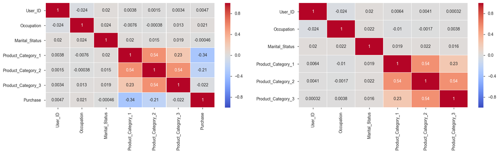

```python
fig = plt.figure(figsize=(20,10))

fig.add_subplot(221)   #top left
sns.heatmap(df.corr(),
            vmin=-1,
            cmap='coolwarm',
            annot=True,
           linecolor='white',
           linewidths='0.1')

fig.add_subplot(222)   #top right
sns.heatmap(df_test.corr(),
            vmin=-1,
            cmap='coolwarm',
            annot=True,
           linecolor='white',
           linewidths='0.1')

plt.show()
```

#### Explore purchase amount by Occupation field.

There are some differences in purchase average (mean) between Occupations.

```python
c = df.groupby('Occupation')['Purchase'].agg(['count','mean']).reset_index()\
        .sort_values('mean', ascending=False)
c.columns = ['Occupation','count','mean']
c
```

|  | Occupation | count | mean |
| --- | --- | --- | --- |
| 17 | 17 | 40043 | 9821.478236 |
| 12 | 12 | 31179 | 9796.640239 |
| 15 | 15 | 12165 | 9778.891163 |
| 8 | 8 | 1546 | 9532.592497 |
| 14 | 14 | 27309 | 9500.702772 |
| 7 | 7 | 59133 | 9425.728223 |
| 16 | 16 | 25371 | 9394.464349 |
| 5 | 5 | 12177 | 9333.149298 |
| 13 | 13 | 7728 | 9306.351061 |
| 6 | 6 | 20355 | 9256.535691 |
| 4 | 4 | 72308 | 9213.980251 |
| 11 | 11 | 11586 | 9213.845848 |
| 3 | 3 | 17650 | 9178.593088 |
| 18 | 18 | 6622 | 9169.655844 |
| 0 | 0 | 69638 | 9124.428588 |
| 10 | 10 | 12930 | 8959.355375 |
| 1 | 1 | 47426 | 8953.193270 |
| 2 | 2 | 26588 | 8952.481683 |
| 20 | 20 | 33562 | 8836.494905 |
| 19 | 19 | 8461 | 8710.627231 |
| 9 | 9 | 6291 | 8637.743761 |

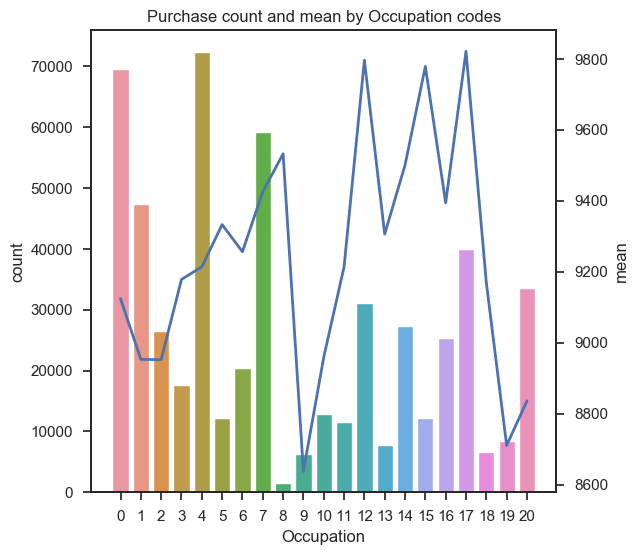

```python
# import seaborn as sns
# import matplotlib.pyplot as plt

# fig = plt.figure(figsize=(10,10))
# fig, ax = plt.subplots(ncols=2)

sns.set(style="ticks", rc={"lines.linewidth": 2})
fig, ax1 = plt.subplots(figsize=(6,6))
ax2 = ax1.twinx()

sns.barplot(x='Occupation', y='count', data=c, ax = ax1)
sns.lineplot(x='Occupation',y='mean', data=c, ax=ax2)
plt.title('Purchase count and mean by Occupation codes')
```

This gives me an idea about grouping occupations by purchase mean & purchase count. I'm not quite sure if it would help increase prediction power. 21 occupations is not a very big number for one-hot labeling. Therefore, lets just leave this field as is and proceed one-hot at modeling stage.

#### Explore Age variable

Now let's explore distribution of purchase amount by Age groups.

[output not shown]

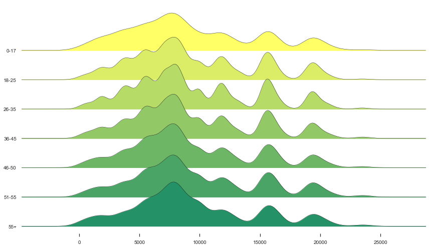

```python
import joypy
from matplotlib import cm
%matplotlib inline

fig, ax1 = plt.subplots(figsize=(12,7))


joypy.joyplot(df[df.Gender == 'M'], by='Age', column='Purchase',ax=ax1,
              linewidth=0.5,
             colormap=cm.summer_r)
```

There is a very slight difference in purchase amount between age groups.

I am going to encode categorical columns using One Hot: Gender, Age, Occupation, City_Category, Stay_In_Current_City_Years, Marital_Status. For high cadinarity columns (Produc Cat), I am looking for a better solution. I may need to look at purchase statistics to group them. In the correlation report, there are some correlations between Product Cats and Purchase. I'm going to look deeper into Product Categories.

#### Explore Product dimension

```python
a = df.groupby('Product_Category_1')['Purchase'].agg(['count','mean']).reset_index()\
        .sort_values('mean', ascending=False)
a.columns = ['Product_Category_1','count','mean']
a
```

|  | Product_Category_1 | count | mean |
| --- | --- | --- | --- |
| 9 | 10 | 5125 | 19675.570927 |
| 6 | 7 | 3721 | 16365.689600 |
| 5 | 6 | 20466 | 15838.478550 |
| 8 | 9 | 410 | 15537.375610 |
| 14 | 15 | 6290 | 14780.451828 |
| 15 | 16 | 9828 | 14766.037037 |
| 0 | 1 | 140378 | 13606.218596 |
| 13 | 14 | 1523 | 13141.625739 |
| 1 | 2 | 23864 | 11251.935384 |
| 16 | 17 | 578 | 10170.759516 |
| 2 | 3 | 20213 | 10096.705734 |
| 7 | 8 | 113925 | 7498.958078 |
| 4 | 5 | 150933 | 6240.088178 |
| 10 | 11 | 24287 | 4685.268456 |
| 17 | 18 | 3125 | 2972.864320 |
| 3 | 4 | 11753 | 2329.659491 |
| 11 | 12 | 3947 | 1350.859894 |
| 12 | 13 | 5549 | 722.400613 |
| 19 | 20 | 2550 | 370.481176 |
| 18 | 19 | 1603 | 37.041797 |

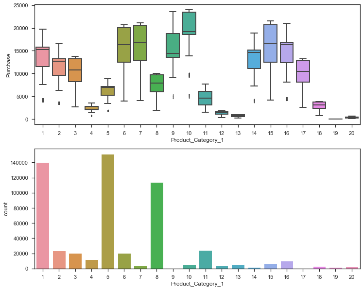

```python
fig = plt.figure(figsize=(12,10))
ax1 = fig.add_subplot(211)
sns.boxplot(x="Product_Category_1", y="Purchase", data=df, fliersize='0.5')

ax2 = fig.add_subplot(212)
sns.barplot(a['Product_Category_1'],a['count'])
```

Clearly, purchase amount distribution varies ammong Product_Categories_1. Cat 1, 5, 8 with large number of purchase shows a clear different purchase amount distribution. Cat 1 has higher purchase median among the three.

As product dimension shows some interesting pattern, I continue analyzing Product_ID, which is more granular than Product Categories.

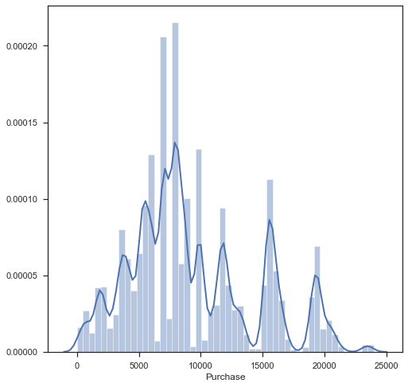

```python
# Purchase amount (each transaction) distribution
plt.figure(figsize=(8,8))
sns.distplot(df['Purchase'])
plt.show()
```

```python
a = df.groupby('Purchase')['Product_ID'].nunique().reset_index()
a.columns =['Purchase_amount','Number_of_transactions']
```

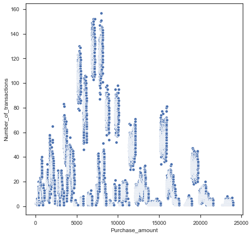

```python
plt.figure(figsize=(8,8))
sns.scatterplot(x='Purchase_amount', y='Number_of_transactions', data=a)
```

```python
a = df.groupby('Product_ID')['Purchase'].agg({'std','mean'}).reset_index()
a.columns =['Product_ID','Prod_std','Prod_mean']
a['Prod_std'].fillna(0, inplace=True)
a['Prod_mean'].fillna(0, inplace=True)
# b = a[a['Prod_count'] <= 200]
b= copy.deepcopy(a)

from sklearn.cluster import KMeans
from sklearn.preprocessing import StandardScaler

scaler = StandardScaler()
c= scaler.fit_transform(b[['Prod_std','Prod_mean']])

kmeans = KMeans(n_clusters=5)
kmeans.fit(c)

c_df = pd.DataFrame(c)

c_df['cluster'] = kmeans.labels_

arr1 = np.array(kmeans.cluster_centers_)
arr2 = np.array([0,1,2,3,4]).reshape((5,1))
centroids1 = np.concatenate((arr1,arr2), axis=1)
df_cen = pd.DataFrame(centroids1, columns=['std_centr','mean_centr','cluster'])
df_cen['cluster']=df_cen['cluster'].astype(int)
c_df = pd.merge(c_df,df_cen,on='cluster', how='left')


c_df = pd.concat([c_df.reset_index(drop=True),
                  b[['Product_ID']].reset_index(drop=True)],
                 axis=1,ignore_index= True)

c_df.columns = ['Prod_std','Prod_mean','cluster',
                'std_centr','mean_centr','Product_ID']
```

```python
c_df.sample(5)
```

|  | Prod_std | Prod_mean | cluster | std_centr | mean_centr | Product_ID |
| --- | --- | --- | --- | --- | --- | --- |
| 417 | 1.459743 | 0.653937 | 3 | 0.870638 | 0.387973 | P00042542 |
| 228 | 0.575163 | -0.010673 | 3 | 0.870638 | 0.387973 | P00023342 |
| 573 | -0.434687 | -0.381437 | 1 | -0.376495 | -0.447605 | P00058442 |
| 3617 | -0.337088 | -0.296210 | 1 | -0.376495 | -0.447605 | P0098542 |
| 1238 | -1.478946 | 1.977962 | 4 | 0.857066 | 1.873682 | P00133142 |

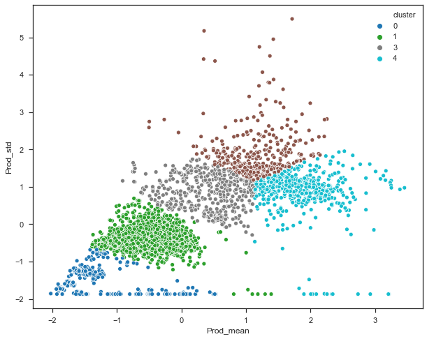

```python
plt.figure(figsize=(10,8))
sns.scatterplot(c_df['Prod_mean'], c_df['Prod_std'], hue=c_df['cluster'],palette='tab10')
```

Each Product_ID is segmented based on its Purchase statistics: Purchase amount average and Purchase amount standard deviation. There are 5 typical groups of products:

- Segment 1: Small purchase amount, small fluctuations
- Segment 2: Medium purchase amount, small fluctuations
- Segment 3: Large purchase amount, small fluctuations
- Segment 4: Medium purchase amount, medium fluctuations
- Segment 5: Large purchase amount, large fluctuations

Beside Product Category, Product segments as above could be useful in prediction model.

It seems Product dimension would provide certain prediction value because there are some different in purchase statistics for different product groups. I'm going to see deeper into Product_ID by looking at the distribution of the avarage and std values of the purchase.

#### More research about Product_ID

```python
# Reducing boundaries to decrease RMSE
cutoff_purchase = np.percentile(df['Purchase'], 99.9)  # 99.9 percentile
a = copy.deepcopy(df)
a.ix[a['Purchase'] > cutoff_purchase, 'Purchase'] = cutoff_purchase
b = a.groupby('Product_ID')['Purchase'].agg({'mean','std'}).reset_index()
b.head()
```

|  | Product_ID | std | mean |
| --- | --- | --- | --- |
| 0 | P00000142 | 2305.175261 | 11143.642361 |
| 1 | P00000242 | 3170.603417 | 10551.851064 |
| 2 | P00000342 | 1824.925693 | 5313.422131 |
| 3 | P00000442 | 1664.088125 | 4795.358696 |
| 4 | P00000542 | 1724.458154 | 5417.530201 |

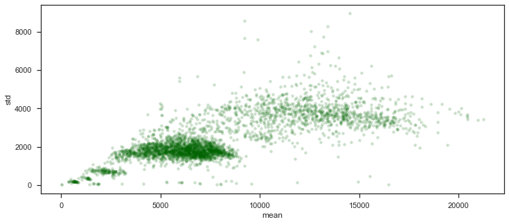

```python
%matplotlib inline
plt.figure(figsize=(12,5))
# sns.scatterplot(b['mean'],b['std'], s=20, alpha=0.3, color='darkgreen')
sns.regplot(b['mean'],b['std'], fit_reg=False, scatter_kws={"color":"darkgreen","alpha":0.2,"s":20} )
# sns.plt.show()
```

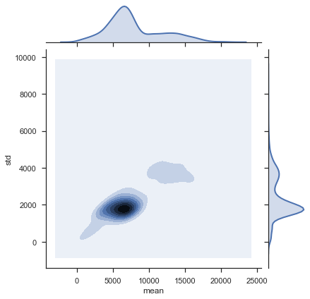

```python
%matplotlib inline
plt.figure(figsize=(16,8))
sns.jointplot(b['mean'],b['std'], kind='kde')
# sns.jointplot(x1, x2, kind="kde", height=7, space=0)
```

There are two distinct groups of Products. The first group includes dominant number of products. These purchases have an medium purchase amount and medium variance. The second group includes smaller number of products. These purchases have large average purchase amount and high purchase amount variance. The distinction in mean and std values between Product_ID can be used in predictive model (label statistics features). However, I would try this feature engineering method but I'm aware that this may cause label information leaking which may lead to overfitting.

#### Explore User_ID data

```python
e = df.groupby('Purchase')['User_ID'].nunique().reset_index()
e.columns =['Purchase_point','count']
```

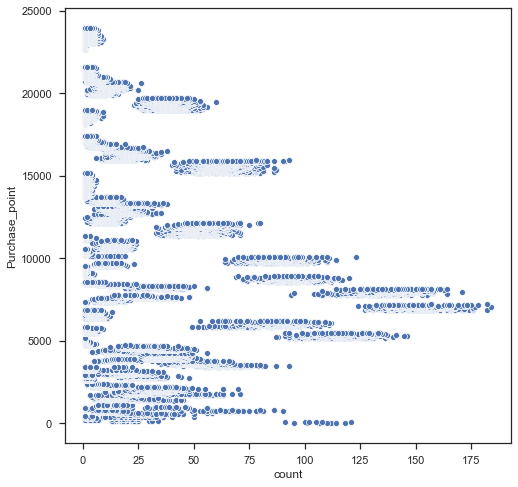

```python
import seaborn as sns
plt.figure(figsize=(8,8))
sns.scatterplot(y='Purchase_point', x='count', data=e)
```

```python
e = df.groupby('User_ID')['Purchase'].agg({'std','mean'}).reset_index()
e.columns =['User_ID','U_std','U_mean']
e['U_std'].fillna(0, inplace=True)
e['U_mean'].fillna(0, inplace=True)

f= copy.deepcopy(e)

from sklearn.cluster import KMeans
from sklearn.preprocessing import StandardScaler

scaler = StandardScaler()
g= scaler.fit_transform(f[['U_std','U_mean']])

kmeans = KMeans(n_clusters=6)
kmeans.fit(g)

g_df = pd.DataFrame(g)

g_df['cluster'] = kmeans.labels_

arr1 = np.array(kmeans.cluster_centers_)
arr2 = np.array([0,1,2,3,4,5]).reshape((6,1))
centroids1 = np.concatenate((arr1,arr2), axis=1)
df_cen = pd.DataFrame(centroids1, columns=['std_centr','mean_centr','cluster'])
df_cen['cluster']=df_cen['cluster'].astype(int)
g_df = pd.merge(g_df,df_cen,on='cluster', how='left')


g_df = pd.concat([g_df.reset_index(drop=True),
                  f[['User_ID']].reset_index(drop=True)],
                 axis=1,ignore_index= True)

g_df.columns = ['U_std','U_mean','cluster',
                'std_centr','mean_centr','U_ID']
```

```python
g_df.sample(5)
```

|  | U_std | U_mean | cluster | std_centr | mean_centr | U_ID |
| --- | --- | --- | --- | --- | --- | --- |
| 4735 | 0.907960 | 0.806446 | 2 | 1.476784 | 1.044305 | 1004857 |
| 5504 | 0.180470 | 0.361492 | 0 | 0.136658 | 0.451316 | 1005646 |
| 4136 | 0.551074 | 0.537286 | 0 | 0.136658 | 0.451316 | 1004247 |
| 3367 | -1.704133 | 4.201147 | 1 | 0.029676 | 2.120685 | 1003461 |
| 3682 | -2.019245 | -0.206473 | 3 | -1.618786 | -1.248473 | 1003782 |

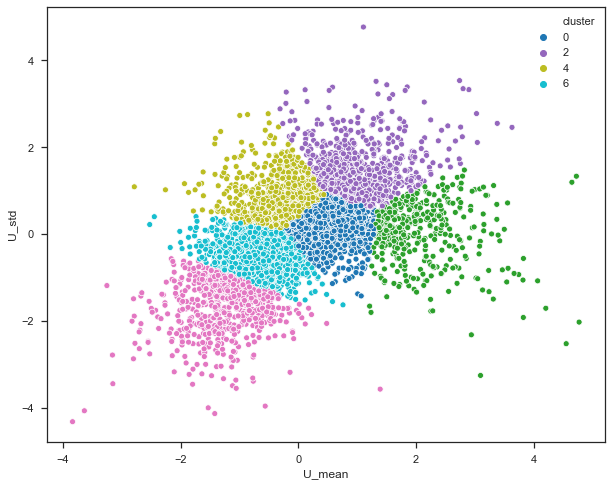

```python
plt.figure(figsize=(10,8))
sns.scatterplot(g_df['U_mean'], g_df['U_std'], hue=g_df['cluster'],palette='tab10')
```